# Notebook

### Web Information Retrieval and Data Mining - Assignment 3

```
Student: SAMUELS, EWOUD (0954698)
```

#### Answer 1.1, Baseline (4p)

- Dense network, at least 3 layers, shaped like a pyramid
  - Last layer: 10 nodes, sigmoid.
  - Loss: categorical cross-entropy. Metric: accuracy
- No preprocessing, regularization. Get at least 70% accuracy.
- Explain design decisions. Discuss performance.
  - Does it overfit (large/growing gap between loss and val_loss)?

[output not shown]

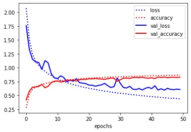

```
Model: "sequential_5"
_________________________________________________________________
Layer (type)                 Output Shape              Param #
=================================================================
flatten_5 (Flatten)          (None, 3072)              0
_________________________________________________________________
dense_18 (Dense)             (None, 256)               786688
_________________________________________________________________
dense_19 (Dense)             (None, 128)               32896
_________________________________________________________________
dense_20 (Dense)             (None, 10)                1290
=================================================================
Total params: 820,874
Trainable params: 820,874
Non-trainable params: 0
_________________________________________________________________
None
def build_model_1_1(input_shape=(32,32,3), kernel_regularizer=None):
    model_1_1 = models.Sequential()
    model_1_1.add(layers.Flatten(input_shape=input_shape))
    model_1_1.add(layers.Dense(256, kernel_regularizer=kernel_regularizer, activation='relu'))
    model_1_1.add(layers.Dense(128, kernel_regularizer=kernel_regularizer, activation='relu'))
    model_1_1.add(layers.Dense(10, kernel_regularizer=kernel_regularizer, activation='softmax'))
    model_1_1.compile(optimizer='sgd',
              loss='categorical_crossentropy',
              metrics=['accuracy'])
    return model_1_1
```

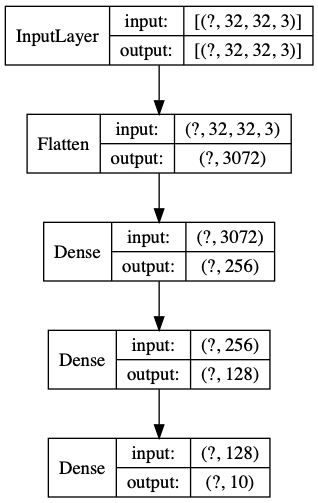

#### Answer 1.2, Preprocess (2p)

- Convert images to greyscale, other preprocessing optional.
  - Input shape should be (32,32,1)
- Explain design decisions. Is it better? Why (not)?
  - Color information is likely not so useful for classification. Greyscale makes the network smaller, less parameters to learn, less likely to overfit.

```
I turned the image into greyscale. The validation accuracy and loss converge more smoothly. Apart from this no differences were observed. Since the performance does not decrease I conclude that no crucial information was lost in the pre-processing.  (length: 250)

Max val score: 82.90%
```

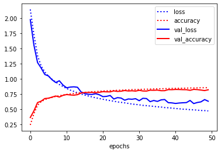

```
Model: "sequential_3"
_________________________________________________________________
Layer (type)                 Output Shape              Param #
=================================================================
flatten_3 (Flatten)          (None, 1024)              0
_________________________________________________________________
dense_9 (Dense)              (None, 256)               262400
_________________________________________________________________
dense_10 (Dense)             (None, 128)               32896
_________________________________________________________________
dense_11 (Dense)             (None, 10)                1290
=================================================================
Total params: 296,586
Trainable params: 296,586
Non-trainable params: 0
_________________________________________________________________
None
def build_model_1_2():
    model_1_2 = build_model_1_1(input_shape=(32,32,1))
    return model_1_2
```

#### Answer 1.3, Tune (4p)

- Regularize the model. What works best?
  - Should consider batch normalization, dropout, l1/l2 regularization (or Nesterov)
- Tune other hyperparameters (e.g. learning rate, batch size,...) as you see fit.
  - At least consider tuning learning rate, ideally also momentum, decay, other optimizers
- Explain your findings and final design decisions. Discuss the results.
  - Should be better, at least it shouldn't overfit

[output not shown]

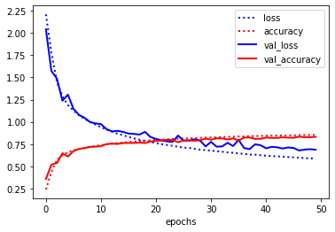

```
def build_model_1_3():
    return build_model_1_1(input_shape=(32,32,1), kernel_regularizer=regularizers.l2(0.0001))
```

#### Answer 2.1, ConvNet (7p)

- Build a sequential ConvNet, get at least 90% accuracy.
  - Conv2D layers, input shape (32,32,1)
  - Consider using blocks of Conv2D layers with maxpooling in between
  - Use zero-padding in Conv2D layers because the images are small
  - At least one dense hidden layer and dense output layer (sigmoid)
  - Consider adding batch normalization, dropout
  - Consider small dropout rates in beginning, larger dropout rates later in network
  - Consider other optimizers and tuning learning rate, momentum,...
- Explain what you did and why (800 chars). Is it working well?
  - Should be quite elaborate and sensible

[output not shown]

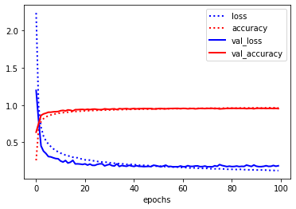

```
Model: "sequential_6"
_________________________________________________________________
Layer (type)                 Output Shape              Param #
=================================================================
conv2d_18 (Conv2D)           (None, 32, 32, 32)        320
_________________________________________________________________
batch_normalization_21 (Batc (None, 32, 32, 32)        128
_________________________________________________________________
conv2d_19 (Conv2D)           (None, 32, 32, 32)        9248
_________________________________________________________________
batch_normalization_22 (Batc (None, 32, 32, 32)        128
_________________________________________________________________
max_pooling2d_9 (MaxPooling2 (None, 16, 16, 32)        0
_________________________________________________________________
dropout_12 (Dropout)         (None, 16, 16, 32)        0
_________________________________________________________________
conv2d_20 (Conv2D)           (None, 16, 16, 64)        18496
_________________________________________________________________
batch_normalization_23 (Batc (None, 16, 16, 64)        256
_________________________________________________________________
conv2d_21 (Conv2D)           (None, 16, 16, 64)        36928
_________________________________________________________________
batch_normalization_24 (Batc (None, 16, 16, 64)        256
_________________________________________________________________
max_pooling2d_10 (MaxPooling (None, 8, 8, 64)          0
_________________________________________________________________
dropout_13 (Dropout)         (None, 8, 8, 64)          0
_________________________________________________________________
conv2d_22 (Conv2D)           (None, 8, 8, 128)         73856
_________________________________________________________________
batch_normalization_25 (Batc (None, 8, 8, 128)         512
_________________________________________________________________
conv2d_23 (Conv2D)           (None, 8, 8, 128)         147584
_________________________________________________________________
batch_normalization_26 (Batc (None, 8, 8, 128)         512
_________________________________________________________________
max_pooling2d_11 (MaxPooling (None, 4, 4, 128)         0
_________________________________________________________________
dropout_14 (Dropout)         (None, 4, 4, 128)         0
_________________________________________________________________
```

[output cut: 27 more lines]

```
    model_2_1.add(layers.MaxPooling2D((2, 2)))
    model_2_1.add(layers.Dropout(0.4))
    model_2_1.add(layers.Conv2D(128, (3, 3), activation='relu', padding='same'))
    model_2_1.add(layers.BatchNormalization())
    model_2_1.add(layers.Conv2D(128, (3, 3), activation='relu', padding='same'))
    model_2_1.add(layers.BatchNormalization())
    model_2_1.add(layers.MaxPooling2D((2, 2)))
    model_2_1.add(layers.Dropout(0.5))
    model_2_1.add(layers.Flatten())
    model_2_1.add(layers.Dense(128, activation='relu'))
    model_2_1.add(layers.BatchNormalization())
    model_2_1.add(layers.Dropout(0.55))
    model_2_1.add(layers.Dense(10, activation='softmax'))
    model_2_1.compile(optimizer='sgd', loss='categorical_crossentropy', metrics=['accuracy'])
    return model_2_1
```

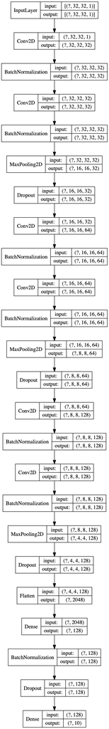

#### Answer 2.2, Data Augmentation (3p)

- Augment the preprocessed training data.
  - Use small variations (small shifts up-down, left-right) of flips becasue the images are small
  - Large shifts and rotations distort the image too much
- Explain what you did and why. Discuss the performance of the model.

[output not shown]

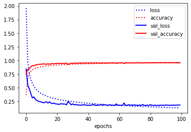

```
data_generator = ImageDataGenerator(
    rotation_range=8,
    zoom_range=[0.95, 1.05],
    height_shift_range=0.10,
    shear_range=0.15
)
```

#### Answer 3.1, Misclassifications (2p)

[output not shown]

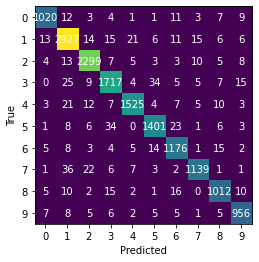

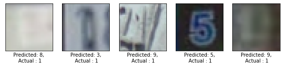

#### Answer 3.2, Activations (4p)

- Retrieve and visualize the activations for one example
- For every filter for different convolutional layers (at different depths in the network).
- Give an explanation. Is your model indeed learning something useful?
  - Should detect edges etc in first layers, higher-order object (e.g. interesting regions) in deeper layers.

[output not shown]

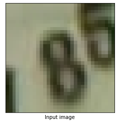

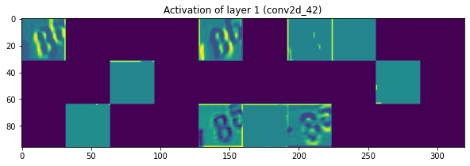

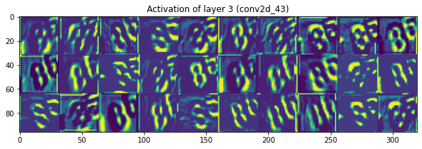

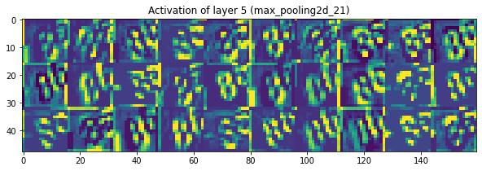

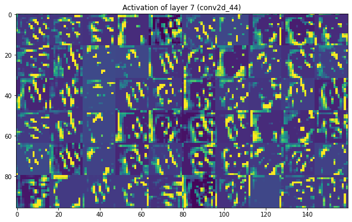

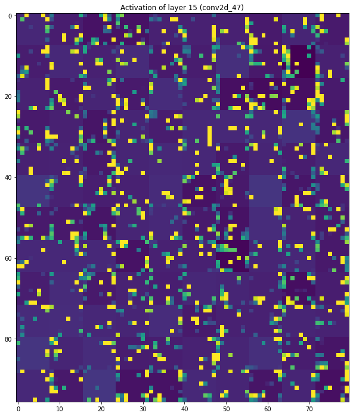

#### Answer 3.3, Class activation map (4p)

- Show a class activation map for your last convolutional layer
- Superimpose the activation map over the image, or plot side by side
  - Should make sense, detect interesting regions to classify the number

[output not shown]

#### Answer 4.1, Fast feature extraction (5p)

- Import the VGG16 model, pretrained on ImageNet
- Freeze convolutional base, adds a dense layer
- Consider unfreezing the last few convolutional layers and evaluate whether that works better
  - Check if they do. It is very likely to help.
- Discuss the observed performance
  - Should get around 80% accuracy

[output not shown]

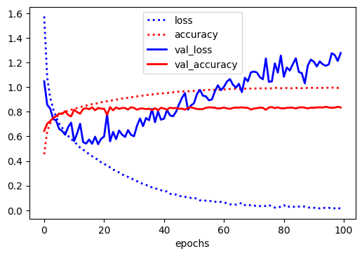

```
Model: "model_64"
_________________________________________________________________
Layer (type)                 Output Shape              Param #
=================================================================
input_35 (InputLayer)        [(None, 32, 32, 3)]       0
_________________________________________________________________
block1_conv1 (Conv2D)        (None, 32, 32, 64)        1792
_________________________________________________________________
block1_conv2 (Conv2D)        (None, 32, 32, 64)        36928
_________________________________________________________________
block1_pool (MaxPooling2D)   (None, 16, 16, 64)        0
_________________________________________________________________
block2_conv1 (Conv2D)        (None, 16, 16, 128)       73856
_________________________________________________________________
block2_conv2 (Conv2D)        (None, 16, 16, 128)       147584
_________________________________________________________________
block2_pool (MaxPooling2D)   (None, 8, 8, 128)         0
_________________________________________________________________
block3_conv1 (Conv2D)        (None, 8, 8, 256)         295168
_________________________________________________________________
block3_conv2 (Conv2D)        (None, 8, 8, 256)         590080
_________________________________________________________________
block3_conv3 (Conv2D)        (None, 8, 8, 256)         590080
_________________________________________________________________
block3_pool (MaxPooling2D)   (None, 4, 4, 256)         0
_________________________________________________________________
block4_conv1 (Conv2D)        (None, 4, 4, 512)         1180160
_________________________________________________________________
block4_conv2 (Conv2D)        (None, 4, 4, 512)         2359808
_________________________________________________________________
block4_conv3 (Conv2D)        (None, 4, 4, 512)         2359808
_________________________________________________________________
block4_pool (MaxPooling2D)   (None, 2, 2, 512)         0
_________________________________________________________________
block5_conv1 (Conv2D)        (None, 2, 2, 512)         2359808
_________________________________________________________________
block5_conv2 (Conv2D)        (None, 2, 2, 512)         2359808
_________________________________________________________________
block5_conv3 (Conv2D)        (None, 2, 2, 512)         2359808
_________________________________________________________________
```

[output cut: 20 more lines]

```

    for layer in base_model.layers[:-4]:
        layer.trainable = False

    output = base_model.output
    output = layers.Flatten()(output)
    output = layers.Dropout(0.5)(output)
    output = layers.Dense(128, activation='relu')(output)
    output = layers.Dropout(0.5)(output)
    output = layers.Dense(10, activation='softmax')(output)

    model_4_1 = Model(inputs=base_model.input, outputs=output)
#     optimizer =
    model_4_1.compile(optimizer='sgd', loss='categorical_crossentropy', metrics=['accuracy'])#0.9 0.001
    return model_4_1
```

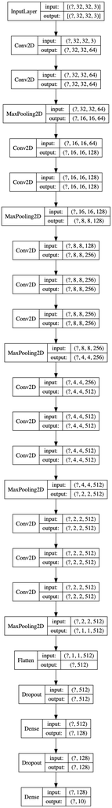

#### Answer 4.2, Embeddings (5p)

- Generate embeddings with the trained convolutional part of model_4_1 (without the dense layer)
- Embed the training and test data and store them to disk
- Build and evaluate a pipeline on the embedded data
  - Check if pipeline makes sense (e.g. use models that can handle many dimensions)
- Describe what you did and what you observed (max 800 chars).
  - Consider different models, preprocessing, tuning, etc.
  - Check performance (see original Submission.html) when in doubt. We did not run all the evaluations because it takes too long, and the output is ill-defined.

[output not shown]

```
Running time: 56.70 seconds
Last modified: May 26, 2020
scikit-learn version: 0.23.1
```